# Word order constraints on event-internal modifiers - Experiment 1: Likert Scale study on Anaphoricity

Tibor Kiss 10.01.2022

```r
library(ordinal)
library(tidyverse)
library(emmeans)

show(version)
```

```
##                _
## platform       x86_64-apple-darwin17.0
## arch           x86_64
## os             darwin17.0
## system         x86_64, darwin17.0
## status
## major          4
## minor          1.2
## year           2021
## month          11
## day            01
## svn rev        81115
## language       R
## version.string R version 4.1.2 (2021-11-01)
## nickname       Bird Hippie
```

#### Introduction

This document describes the necessary analysis of Experiment 1 (LS) for event-internal modifiers (second stage). We have chosen a model with a rather complex random structure, which however, similar to the model for the forced choice study on thematic integration, reveals differences in by-subject variability.

#### Read in data set

```r
exp_anaphoricity_ls.test.data <-
  read.csv("../Data/LikertSkala_test.csv", fileEncoding = "UTF-8", stringsAsFactors = TRUE)

exp_anaphoricity_ls.test.data$CONDITION_NO <- factor(exp_anaphoricity_ls.test.data$CONDITION_NO)

exp_anaphoricity_ls.test.data$FCT_ANSWER <-
  factor(exp_anaphoricity_ls.test.data$ANSWER, ordered = TRUE)

exp_anaphoricity_ls.test.data$ENCODING <-
  factor(as.character(exp_anaphoricity_ls.test.data$ENCODING))

exp_anaphoricity_ls.test.data$KEY_CONDITION = relevel(exp_anaphoricity_ls.test.data$KEY_CONDITION, "PP>OBJ") ## CONDITION_NO 1

## more illustrative variable names
exp_anaphoricity_ls.test.data$POSITION <- factor(exp_anaphoricity_ls.test.data$KEY_CONDITION)
exp_anaphoricity_ls.test.data$subjects <- factor(exp_anaphoricity_ls.test.data$workerId)
exp_anaphoricity_ls.test.data$items <- factor(exp_anaphoricity_ls.test.data$ENCODING)
```

#### Empirical distribution of judgments

Number of accepted participants: 51.

```r
exp_anaphoricity_ls.dist.summary <- exp_anaphoricity_ls.test.data %>%
  select(workerId, CONDITION_NO) %>% table() %>% as.data.frame()
exp_anaphoricity_ls.dist.summary %>% filter(Freq < 18)
```

```
## [1] workerId     CONDITION_NO Freq
## <0 Zeilen> (oder row.names mit Länge 0)
```

Each participant has seen 18 test items per condition, since no participant has seen less than 18 test items per condition (8->).

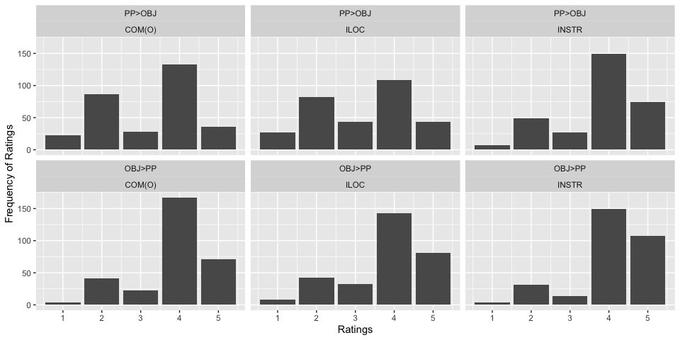

```r
exp_anaphoricity_ls.test.summary <-
  exp_anaphoricity_ls.test.data %>%
  group_by(POSITION, ADVERBIAL_TYPE, ANSWER) %>%
  summarise(count = n())

ggplot(exp_anaphoricity_ls.test.summary, aes(x = ANSWER, y = count)) +
  geom_bar(stat = "identity", position = "dodge", show.legend = FALSE) +
  facet_wrap(POSITION~ADVERBIAL_TYPE) +
  labs(x = "Ratings", y = "Frequency of Ratings")
```

### Random slope model for items and subjects without interaction

This model does not make use of interaction of the fixed effects but assumes an interaction for the random effects so that random effects for each condition (3 x 2) are modelled for subjects and thus can be compared. (Items of course do not vary w.r.t. `ADVERBIAL_TYPE`.)

#### Definition of model

```r
exp_anaphoricity_ls.test.data$ADVERBIAL_TYPE <-
  relevel(factor(exp_anaphoricity_ls.test.data$ADVERBIAL_TYPE), ref = "INSTR")
exp_anaphoricity_ls.test.data$POSITION <-
  relevel(factor(exp_anaphoricity_ls.test.data$POSITION), ref = "PP>OBJ")

exp_anaphoricity_ls.clmm <-
  clmm(FCT_ANSWER  ~ ADVERBIAL_TYPE + POSITION +
         (0 + ADVERBIAL_TYPE * POSITION | subjects) +
         (0 + POSITION | items),
       exp_anaphoricity_ls.test.data)
options(width = 300)
summary(exp_anaphoricity_ls.clmm)
```

```
## Cumulative Link Mixed Model fitted with the Laplace approximation
##
## formula: FCT_ANSWER ~ ADVERBIAL_TYPE + POSITION + (0 + ADVERBIAL_TYPE *      POSITION | subjects) + (0 + POSITION | items)
## data:    exp_anaphoricity_ls.test.data
##
##  link  threshold nobs logLik   AIC     niter       max.grad cond.H
##  logit flexible  1836 -2107.63 4277.27 5104(26313) 2.57e-03 4.5e+02
##
## Random effects:
##  Groups   Name                                Variance Std.Dev. Corr
##  subjects ADVERBIAL_TYPEINSTR                 2.3987   1.5488
##           ADVERBIAL_TYPECOM(O)                2.3873   1.5451    0.748
##           ADVERBIAL_TYPEILOC                  2.1802   1.4766    0.898  0.561
##           POSITIONOBJ>PP                      0.8843   0.9404   -0.078 -0.109 -0.088
##           ADVERBIAL_TYPECOM(O):POSITIONOBJ>PP 0.7158   0.8460    0.240 -0.334  0.487 -0.178
##           ADVERBIAL_TYPEILOC:POSITIONOBJ>PP   0.6667   0.8165   -0.430  0.083 -0.595 -0.386 -0.790
##  items    POSITIONPP>OBJ                      0.5416   0.7359
##           POSITIONOBJ>PP                      0.6100   0.7810   0.781
## Number of groups:  subjects 51,  items 36
##
## Coefficients:
##                      Estimate Std. Error z value Pr(>|z|)
## ADVERBIAL_TYPECOM(O)  -0.9571     0.3479  -2.751  0.00594 **
## ADVERBIAL_TYPEILOC    -1.0353     0.3396  -3.049  0.00230 **
## POSITIONOBJ>PP         1.1916     0.1738   6.856 7.08e-12 ***
## ---
## Signif. codes:  0 '***' 0.001 '**' 0.01 '*' 0.05 '.' 0.1 ' ' 1
##
## Threshold coefficients:
##     Estimate Std. Error z value
## 1|2  -4.5321     0.3557 -12.740
## 2|3  -2.0566     0.3301  -6.231
## 3|4  -1.3708     0.3278  -4.182
## 4|5   1.7521     0.3286   5.333
```

```r
exp_anaphoricity_ls.clmm2 <-
  clmm(FCT_ANSWER  ~ ADVERBIAL_TYPE * POSITION +
         (0 + ADVERBIAL_TYPE * POSITION| subjects) +
         (0 + POSITION | items),
       exp_anaphoricity_ls.test.data)

summary(exp_anaphoricity_ls.clmm2)
```

```
## Cumulative Link Mixed Model fitted with the Laplace approximation
##
## formula: FCT_ANSWER ~ ADVERBIAL_TYPE * POSITION + (0 + ADVERBIAL_TYPE *      POSITION | subjects) + (0 + POSITION | items)
## data:    exp_anaphoricity_ls.test.data
##
##  link  threshold nobs logLik   AIC     niter       max.grad cond.H
##  logit flexible  1836 -2106.13 4278.25 5248(26494) 6.44e-04 4.7e+02
##
## Random effects:
##  Groups   Name                                Variance Std.Dev. Corr
##  subjects ADVERBIAL_TYPEINSTR                 2.4409   1.5623
##           ADVERBIAL_TYPECOM(O)                2.3606   1.5364    0.753
##           ADVERBIAL_TYPEILOC                  2.1860   1.4785    0.894  0.559
##           POSITIONOBJ>PP                      0.8263   0.9090   -0.133 -0.169 -0.131
##           ADVERBIAL_TYPECOM(O):POSITIONOBJ>PP 0.6776   0.8231    0.317 -0.261  0.554 -0.121
##           ADVERBIAL_TYPEILOC:POSITIONOBJ>PP   0.6432   0.8020   -0.367  0.153 -0.563 -0.342 -0.873
##  items    POSITIONPP>OBJ                      0.5298   0.7279
##           POSITIONOBJ>PP                      0.5880   0.7668   0.818
## Number of groups:  subjects 51,  items 36
##
## Coefficients:
##                                     Estimate Std. Error z value Pr(>|z|)
## ADVERBIAL_TYPECOM(O)                 -1.2042     0.3736  -3.223 0.001266 **
## ADVERBIAL_TYPEILOC                   -1.1833     0.3545  -3.338 0.000843 ***
## POSITIONOBJ>PP                        0.8630     0.2532   3.409 0.000652 ***
## ADVERBIAL_TYPECOM(O):POSITIONOBJ>PP   0.5385     0.3237   1.664 0.096157 .
## ADVERBIAL_TYPEILOC:POSITIONOBJ>PP     0.3758     0.3223   1.166 0.243687
## ---
## Signif. codes:  0 '***' 0.001 '**' 0.01 '*' 0.05 '.' 0.1 ' ' 1
##
## Threshold coefficients:
##     Estimate Std. Error z value
## 1|2  -4.6695     0.3595 -12.990
## 2|3  -2.1878     0.3324  -6.582
## 3|4  -1.5011     0.3298  -4.551
## 4|5   1.6197     0.3300   4.908
```

A comparison of the two models shows that they are not significantly different. We will thus keep the model with interaction in the random effects but no interaction in the fixed effects:

```r
comp <- anova(exp_anaphoricity_ls.clmm, exp_anaphoricity_ls.clmm2)

show(comp)
```

```
## Likelihood ratio tests of cumulative link models:
##
##                           formula:
## exp_anaphoricity_ls.clmm  FCT_ANSWER ~ ADVERBIAL_TYPE + POSITION + (0 + ADVERBIAL_TYPE * POSITION | subjects) + (0 + POSITION | items)
## exp_anaphoricity_ls.clmm2 FCT_ANSWER ~ ADVERBIAL_TYPE * POSITION + (0 + ADVERBIAL_TYPE * POSITION | subjects) + (0 + POSITION | items)
##                           link: threshold:
## exp_anaphoricity_ls.clmm  logit flexible
## exp_anaphoricity_ls.clmm2 logit flexible
##
##                           no.par    AIC  logLik LR.stat df Pr(>Chisq)
## exp_anaphoricity_ls.clmm      31 4277.3 -2107.6
## exp_anaphoricity_ls.clmm2     33 4278.3 -2106.1  3.0122  2     0.2218
```

The random structure of the model reveals that the by-subject variability is reduced under `OBJ > PP`.

#### Effects in the model w/o interaction

Since we have chosen INSTR as reference value, the values for ILOC and COM(O) both show significance, but it should be kept in mind that they are practically identical. The general effect of `POSITION == OBJ > PP` is 3.292. The effects for COM(O) and ILOC in `POSITION == PP > OBJ` are 0.384, and 0.355, respectively.

#### Model predictions

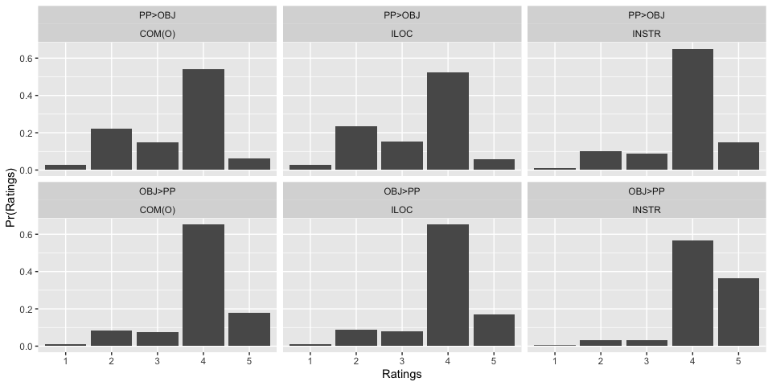

```r
pred <-function(eta, theta, cat = 1:(length(theta)+1), inv.link= plogis){
  Theta <- c(-1e3, theta, 1e3)
  sapply(cat, function(j) inv.link(Theta[j+1] - eta) - inv.link(Theta[j] - eta))
}

exp_anaphoricity_ls.mat <-
  data.frame(
    adv = rep(c(0, exp_anaphoricity_ls.clmm$beta[1],
                exp_anaphoricity_ls.clmm$beta[2]), 2),
    cond = c(rep(0, 3), rep(exp_anaphoricity_ls.clmm$beta[3], 3))
  )

pred.mat <- pred(eta=rowSums(exp_anaphoricity_ls.mat),
                 theta=exp_anaphoricity_ls.clmm$Theta)

exp_anaphoricity_ls.mat$condition <-
  c(rep("PP>OBJ", 3), rep("OBJ>PP", 3))
exp_anaphoricity_ls.mat$adv_type <-
  rep(c("INSTR", "COM(O)", "ILOC"), 2)

exp_anaphoricity_ls.pred <-
  cbind(exp_anaphoricity_ls.mat, pred.mat)

exp_anaphoricity_ls.pred.long <-
  exp_anaphoricity_ls.pred %>%
  gather("1":"5", key = "ANSWER", value = "rating")

exp_anaphoricity_ls.pred.long$condition <-
  relevel(factor(exp_anaphoricity_ls.pred.long$condition), ref = "PP>OBJ")

ggplot(exp_anaphoricity_ls.pred.long, aes(x = ANSWER, y = rating)) +
  geom_bar(stat = "identity", show.legend = FALSE) +
  facet_wrap(condition ~ adv_type) +
  labs(x = "Ratings", y = "Pr(Ratings)")
```

#### Test items in disfavored positions with high ratings

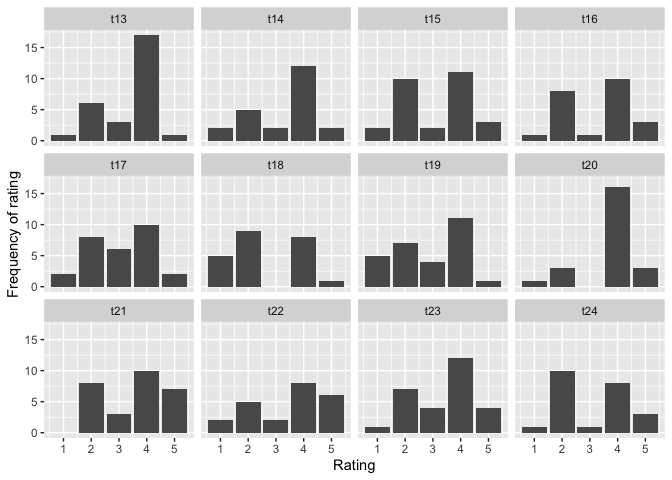

```r
exp_anaphoricity_ls.rating.summary <-
  subset(exp_anaphoricity_ls.test.data,
         ADVERBIAL_TYPE == "COM(O)" & POSITION == "PP>OBJ") %>%
  group_by(ENCODING, ANSWER) %>%
  summarise(count = n()) %>%
  as.data.frame()

ggplot(exp_anaphoricity_ls.rating.summary, aes(x = ANSWER, y = count)) +
  geom_bar(stat = "identity") +
  facet_wrap(~ENCODING) +
  labs(x = "Rating", y = "Frequency of rating")
```

```r
read.csv("../Data/stimuli_test_basic.csv", fileEncoding = "UTF-8") %>%
  filter(ADVERBIAL_TYPE == "COM(O)" & KEY_CONDITION == "PP>OBJ") %>%
  select(ENCODING, ITEM) %>% knitr::kable()
```

| ENCODING | ITEM |
| --- | --- |
| t13 | Lea hat erzählt, dass ein Kleinkrimineller zusammen mit einer Stichwaffe was vergraben hat. Was es war, weiß ich aber nicht. |
| t14 | Ich habe gehört, dass eine Schuldirektorin zusammen mit einer Einladung was verschickt hat. Was es war, weiß ich aber nicht. |
| t15 | Ich habe gehört, dass ein Abgeordneter zusammen mit einem Finanzplan was vorgelegt hat. Was es war, weiß ich aber nicht. |
| t16 | Jan hat erzählt, dass ein Verleger zusammen mit einem Foto was veröffentlicht hat. Was es war, weiß ich aber nicht. |
| t17 | Tim hat erzählt, dass eine Haushälterin zusammen mit einem Handtuch was gewaschen hat. Was es war, weiß ich aber nicht. |
| t18 | Ich habe gehört, dass ein Verleger zusammen mit einem Literaturpreis was verliehen hat. Was es war, weiß ich aber nicht. |
| t19 | Ich habe gehört, dass eine Küchenhilfe zusammen mit einem Schnitzel was eingefroren hat. Was es war, weiß ich aber nicht. |
| t20 | Pia hat erzählt, dass ein Buchhalter zusammen mit einem Überweisungsträger was versandt hat. Was es war, weiß ich aber nicht. |
| t21 | Ich habe gehört, dass ein Minister zusammen mit einer Urkunde was überreicht hat. Was es war, weiß ich aber nicht. |
| t22 | Kai hat erzählt, dass ein Händler zusammen mit einem Gemälde was verkauft hat. Was es war, weiß ich aber nicht. |
| t23 | Eva hat erzählt, dass ein Kellner zusammen mit einer Süßspeise was serviert hat. Was es war, weiß ich aber nicht. |
| t24 | Ich habe gehört, dass ein Hobbykoch zusammen mit einer Knoblauchzehe was püriert hat. Was es war, weiß ich aber nicht. |